# Variable coding for the BPA/BPS vs birth weight

# 1 Intro

In this document we justify the selection of the variables in the **growth ouctomes vs BPA/BPS** analysis model and their coding. We will focus on birth weight as an outcome and extend the conclusions from this report to other outcomes.

We provide a special focus on the many variables measuring tobacco consumption.

# 2 DAG

```
birth_weight = BPA_t1 + BPA_t3 + mom_age + smoking + education + child_sex + parity + pre_preg_bmi + occupation* + gestational_age
```

* occupation included for BPS only

# 3 Descriptive

In this section we provide a brief descriptive of each variable to be included in the model excluding exposure and tobacco.

Numeric vars

| mom_age | mom_bmi | gestational_age_weeks |
| --- | --- | --- |
| Min. :20.56 | Min. :16.97 | Min. :30.71 |
| 1st Qu.:29.91 | 1st Qu.:19.72 | 1st Qu.:39.00 |
| Median :32.19 | Median :21.53 | Median :40.00 |
| Mean :32.52 | Mean :22.39 | Mean :39.75 |
| 3rd Qu.:35.16 | 3rd Qu.:24.02 | 3rd Qu.:40.71 |
| Max. :45.47 | Max. :41.95 | Max. :43.43 |
| NA | NA’s :4 | NA |

Factors

| child_sex | parity | mom_edu_raw |
| --- | --- | --- |
| 1:245 | 0 :205 | 3 : 5 |
| 2:212 | 1 :203 | 4 : 10 |
|  | 2 : 48 | 5 : 11 |
|  | NA’s: 1 | 6 : 52 |
|  |  | 7 :119 |
|  |  | 8 :257 |
|  |  | NA’s: 3 |

# 4 Smoke data

Here we provide a brief descriptive of all the available smoking variables.

**Definition**: Smoke high means >= 1 cig/day

pre-pregnancy

| smoke_pre_detection |
| --- |
| Min. : 0.0000 |
| 1st Qu.: 0.0000 |
| Median : 0.0000 |
| Mean : 0.4721 |
| 3rd Qu.: 0.0000 |
| Max. :15.0000 |
| NA’s :47 |

First trimester

| smoke_n_cig_t1 | smoke_t1 | smoke_high_t1 |
| --- | --- | --- |
| Min. :0.0000 | 0 :402 | 0 :402 |
| 1st Qu.:0.0000 | 1 : 15 | 1 : 15 |
| Median :0.0000 | NA’s: 40 | NA’s: 40 |
| Mean :0.1151 |  |  |
| 3rd Qu.:0.0000 |  |  |
| Max. :9.0000 |  |  |
| NA’s :40 |  |  |

Second trimester

| smoke_n_cig_t2 | smoke_t2 | smoke_high_t2 |
| --- | --- | --- |
| Min. :0.00000 | 0 :401 | 0 :409 |
| 1st Qu.:0.00000 | 1 : 21 | 1 : 10 |
| Median :0.00000 | NA’s: 35 | NA’s: 38 |
| Mean :0.06751 |  |  |
| 3rd Qu.:0.00000 |  |  |
| Max. :7.14286 |  |  |
| NA’s :38 |  |  |

Third trimester

| smoke_n_cig_t3 | smoke_t3 | smoke_high_t3 |
| --- | --- | --- |
| Min. :0.00000 | 0 :402 | 0 :290 |
| 1st Qu.:0.00000 | 1 : 2 | 1 : 1 |
| Median :0.00000 | NA’s: 53 | NA’s:166 |
| Mean :0.00884 |  |  |
| 3rd Qu.:0.00000 |  |  |
| Max. :2.00000 |  |  |
| NA’s :166 |  |  |

Any time during pregnancy

| smoke_any | smoke_any_high |
| --- | --- |
| 0 :396 | 0 :289 |
| 1 : 23 | 1 : 15 |
| NA’s: 38 | NA’s:153 |

# 5 Variable coding

Quick reminder: *Given a set of candidate models for the data, the preferred model is the one with the minimum AIC value*

AIC computed using model presented in intro without exposure

## 5.1 Continuous variables

### 5.1.1 mom_age

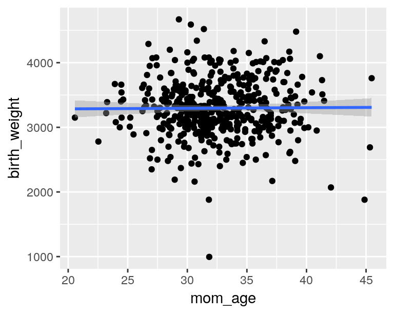

The categorical age is the one provided in bdd_grossess created by Karine.

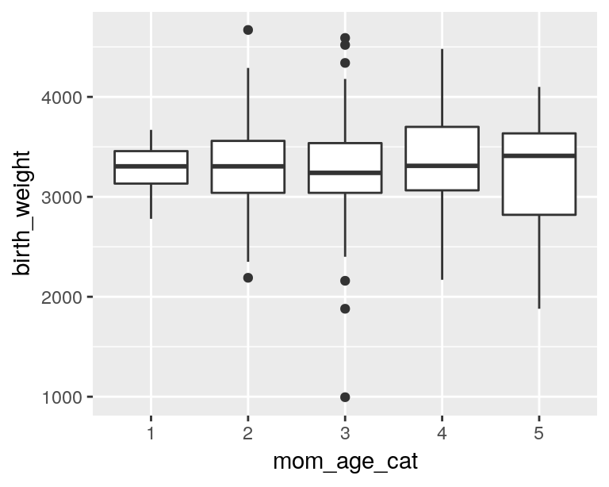

AIC for model with mom age continuous vs categorical

| continuous | categorical |
| --- | --- |
| 6007 | 6011 |

=> `mom_age` best coded as **continuous**

### 5.1.2 mom_bmi

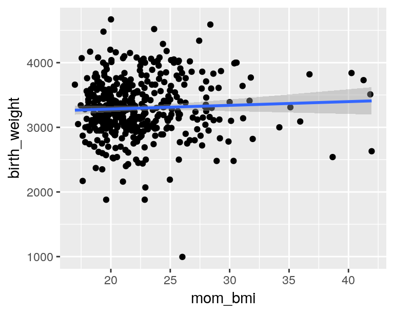

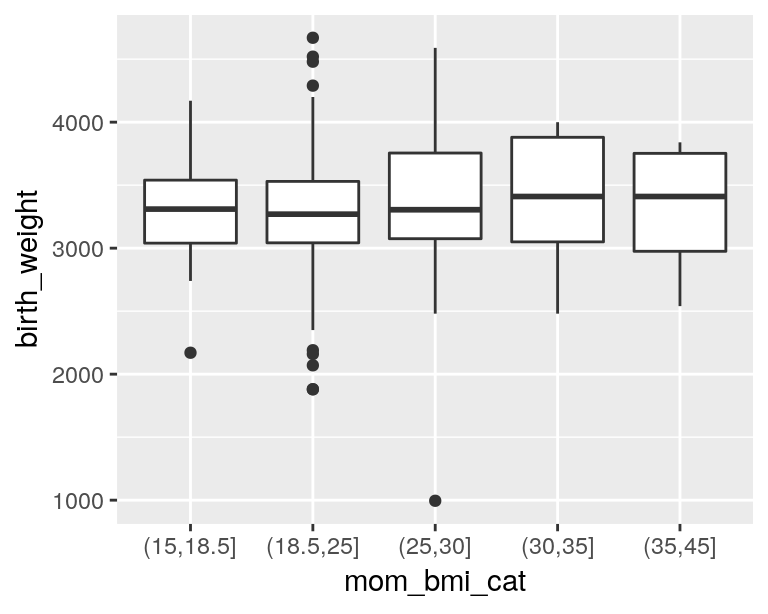

AIC for model with continuous vs categorical

| continuous | categorical |
| --- | --- |
| 6002 | 6007 |

=> `mom_bmi` best coded as **continuous**

### 5.1.3 gestational_age_weeks

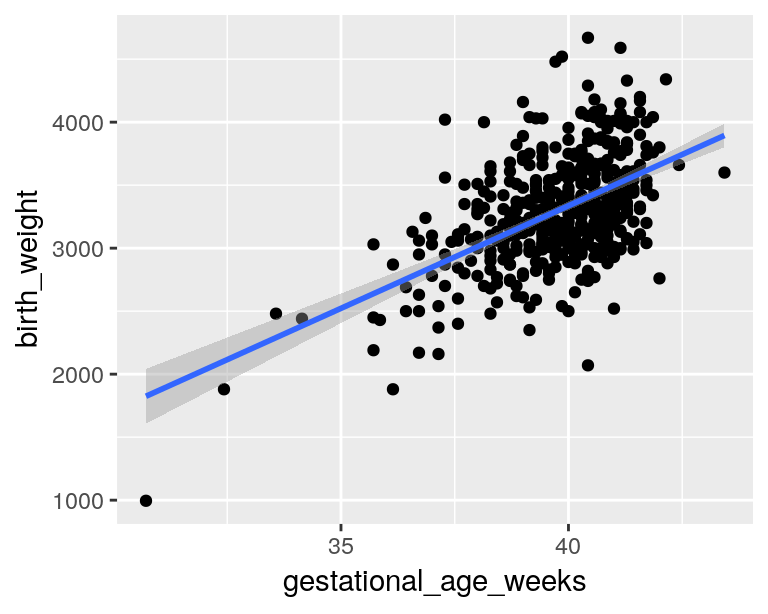

Gestational age divided into 5 equal N categories:

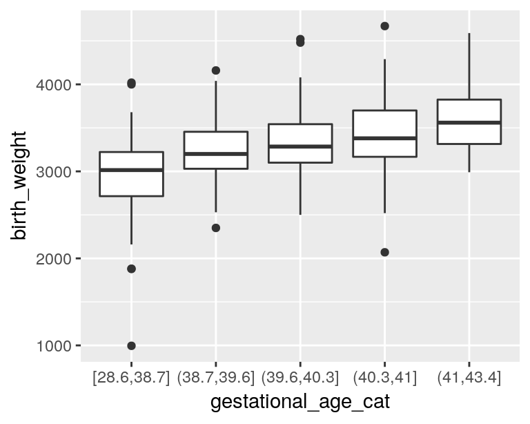

AIC for model with gestational age continuous vs categorical

| continuous | categorical |
| --- | --- |
| 6002 | 6062 |

=> `gestational_age` best coded as **continuous**

## 5.2 Categorical variables

### 5.2.1 mom_education

Here we compare several `mom_education` classifications:

`mom_edu_raw`

- 1 Primaire
- 2 College
- 3 BEP
- 4 CAP
- 5 Lycee
- 6 Bac +2
- 7 Bac +3-4
- 8 >=Bac +5

`mom_edu`

- 1 Primaire/College
- 2 BEP/CAP/Lycee
- 3 Bac +2
- 4 Bac +3-4
- 5 Bac +5

`mom_edu_length`

- 1 Primaire/College/BEP/CAP/Lycee/Bac +2
- 2 Bac +3-4
- 3 Bac +5

`mom_edu_length2`

- 1 Primaire/College/BEP/CAP/Lycee
- 2 Bac +2-3-4
- 3 Bac +5

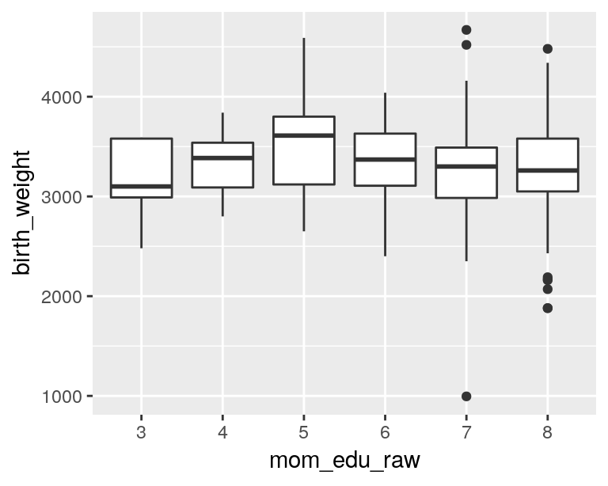

Model with raw coding output:

```
##
## Call:
## lm(formula = birth_weight ~ mom_age + mom_edu_raw + child_sex +
##     parity_cat + mom_bmi + gestational_age_weeks + smoke_t1,
##     data = bw_data)
##
## Residuals:
##      Min       1Q   Median       3Q      Max
## -1366.96  -232.19   -22.31   222.32  1314.43
##
## Coefficients:
##                           Estimate Std. Error t value Pr(>|t|)
## (Intercept)              -4120.179    574.627  -7.170 3.67e-12 ***
## mom_age                      4.416      4.956   0.891 0.373469
## mom_edu_raw4               114.656    222.939   0.514 0.607334
## mom_edu_raw5               310.122    213.361   1.454 0.146870
## mom_edu_raw6               145.494    188.834   0.770 0.441469
## mom_edu_raw7                47.463    184.764   0.257 0.797402
## mom_edu_raw8                91.785    183.313   0.501 0.616860
## child_sex2                 -82.325     36.245  -2.271 0.023661 *
## parity_catSecond or more   127.876     38.061   3.360 0.000855 ***
## mom_bmi                      9.081      4.728   1.921 0.055463 .
## gestational_age_weeks      174.917     12.323  14.194  < 2e-16 ***
## smoke_t11                 -148.067     96.754  -1.530 0.126727
## ---
## Signif. codes:  0 '***' 0.001 '**' 0.01 '*' 0.05 '.' 0.1 ' ' 1
##
## Residual standard error: 360.3 on 398 degrees of freedom
##   (47 observations deleted due to missingness)
## Multiple R-squared:  0.3614, Adjusted R-squared:  0.3438
## F-statistic: 20.48 on 11 and 398 DF,  p-value: < 2.2e-16
```

All model AIC:

AIC for different mom edu classifications

| raw | mom_edu | mom_edu_length | mom_edu_length2 | mom_edu_length3 |
| --- | --- | --- | --- | --- |
| 6005 | 6003 | 6002 | 6004 | 6002 |

- `mom_edu` best coded as
  - 1 Primaire/College/BEP/CAP/Lycee/Bac +2
  - 2 Bac +3-4
  - 3 Bac +5

### 5.2.2 parity

Here we compare

- `parity`
  - First child
  - Second child
  - Third child
- `parity_cat`
  - First child
  - Second child or more

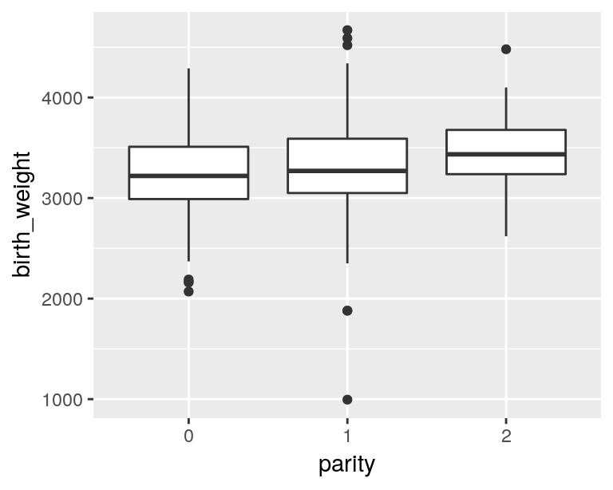

Model with raw coding output:

```
##
## Call:
## lm(formula = birth_weight ~ mom_age + mom_edu_length + child_sex +
##     parity + mom_bmi + gestational_age_weeks + smoke_t1, data = bw_data)
##
## Residuals:
##      Min       1Q   Median       3Q      Max
## -1354.15  -232.67   -22.05   213.80  1328.60
##
## Coefficients:
##                        Estimate Std. Error t value Pr(>|t|)
## (Intercept)           -4031.441    547.562  -7.363 1.04e-12 ***
## mom_age                   3.254      4.984   0.653  0.51417
## mom_edu_lengthLong       47.617     42.576   1.118  0.26407
## mom_edu_lengthShort     104.291     55.375   1.883  0.06038 .
## child_sex2              -78.518     36.138  -2.173  0.03039 *
## parity1                 113.169     39.445   2.869  0.00434 **
## parity2                 202.989     63.054   3.219  0.00139 **
## mom_bmi                   9.771      4.703   2.078  0.03838 *
## gestational_age_weeks   174.315     12.313  14.156  < 2e-16 ***
## smoke_t11              -140.239     94.842  -1.479  0.14002
## ---
## Signif. codes:  0 '***' 0.001 '**' 0.01 '*' 0.05 '.' 0.1 ' ' 1
##
## Residual standard error: 359.7 on 400 degrees of freedom
##   (47 observations deleted due to missingness)
## Multiple R-squared:  0.3605, Adjusted R-squared:  0.3461
## F-statistic: 25.06 on 9 and 400 DF,  p-value: < 2.2e-16
```

All model AIC:

AIC for different parity classifications

| parity | parity_cat |
| --- | --- |
| 6001 | 6002 |

## 5.3 Tobacco

Because the Ns vary from one tobacco var to another, all tobacco models summarized in the following table were performed on the subset of women with all smoke data available.

N = 291

First columns represent the tobacco variable estimates, CI and p, last columns represent the model stats including that variable. Table is sorted in descending adjusted R squared.

| smoke_var | estimate | conf.low | conf.high | p.value | adj.r.squared | AIC | df.residual |
| --- | --- | --- | --- | --- | --- | --- | --- |
| smoke_any_high | -436 | -942 | 71 | 0.091 | 0.325 | 4185 | 277 |
| smoke_high_t1 | -436 | -942 | 71 | 0.091 | 0.325 | 4185 | 277 |
| smoke_high_t2 | -436 | -942 | 71 | 0.091 | 0.325 | 4185 | 277 |
| smoke_t1 | -436 | -942 | 71 | 0.091 | 0.325 | 4185 | 277 |
| smoke_any | -308 | -723 | 108 | 0.146 | 0.323 | 4186 | 277 |
| smoke_t2 | -308 | -723 | 108 | 0.146 | 0.323 | 4186 | 277 |
| smoke_n_cig_t2 | -273 | -665 | 120 | 0.173 | 0.323 | 4186 | 277 |
| smoke_n_cig_t1 | -137 | -336 | 62 | 0.178 | 0.323 | 4186 | 277 |
| smoke_pre_detection | -29 | -78 | 19 | 0.236 | 0.322 | 4186 | 277 |
| smoke_t3 | -38 | -550 | 475 | 0.885 | 0.318 | 4188 | 277 |
| smoke_n_cig_t3 | -20 | -368 | 327 | 0.909 | 0.318 | 4188 | 277 |
| smoke_high_t3 | -31 | -750 | 689 | 0.933 | 0.318 | 4188 | 277 |

# 6 Summary

Matthieu Rolland

2019-09-24